# TWAS Analysis of Diversity Outbred Strain RNAseq Data

Dave Bridges

July 7, 2020

# 1 Purpose

# 2 Experimental Details

The RNA expression data was downloaded from GSE72759 as a matrix file, and compared with genotypes from the Svenson-183 dataset.

# 3 Raw Data

```r
library(readr) #loads the readr package
expression.filename <- "GSE72759_DO192_RNAseq_UpperQuartileNormalized_n21454genes_forGEOSubmission.txt"
expression.data <- read_tsv(expression.filename, show_col_types = F) %>%
  dplyr::rename(ENSEMBL.ID=1)

genotype.filename <- 'Svenson-183_Svenson_DO-MegaMUGA-calls.csv'
genotype.data <- read_csv(genotype.filename,
                          col_types = cols(
  .default = col_character(),
  chr = col_factor(levels=NULL),
  pos = col_double()
))

phenotype.filename <- 'Svenson_HFD_DO_phenotype_V12.csv'
phenotype.data <- read_csv(phenotype.filename)

phenotype.data[phenotype.data=='-999999'] <- NA


mean.expression <-
  expression.data %>%
  dplyr::select(contains(phenotype.data$mouse.id))%>%
  rowMeans()

expression.data <-
   expression.data %>%
   filter(mean.expression>10)
```

# 4 Analysis

Only evaluated gene expression for genes with >10 TPM

## 4.1 Cholesterol Levels

Regressed cholesterol levels by diet and sex

```r
summary.data <-
  phenotype.data %>%
  group_by(sex,diet) %>%
  summarize_at(.vars=vars(chol2), .funs=list(mean=mean,
                                             se=se,
                                             sd=sd,
                                             n=length))

kable(summary.data,caption="Summary statistics for cholesterol levels at 8 weeks")
```

Summary statistics for cholesterol levels at 8 weeks

| sex | diet | mean | se | sd | n |
| --- | --- | --- | --- | --- | --- |
| F | chow | NA | 1.48 | NA | 225 |
| F | hf | NA | 2.40 | NA | 198 |
| M | chow | NA | 1.57 | NA | 224 |
| M | hf | NA | 2.33 | NA | 193 |

```r
library(broom)
lm(chol2~sex*diet, data=phenotype.data) %>%
  tidy %>%
  kable(caption="Global interactions between sex and diet")
```

Global interactions between sex and diet

| term | estimate | std.error | statistic | p.value |
| --- | --- | --- | --- | --- |
| (Intercept) | 78.67 | 1.88 | 41.887 | 0.000 |
| sexM | 17.80 | 2.68 | 6.648 | 0.000 |
| diethf | 34.64 | 2.75 | 12.615 | 0.000 |
| sexM:diethf | -1.86 | 3.94 | -0.474 | 0.636 |

```r
chol.lm <- lm(chol2~sex+diet, data=phenotype.data)
chol.lm.ncd <- lm(chol2~sex, data=filter(phenotype.data, diet=='chow'))

cholesterol.data.ncd <-
  phenotype.data %>%
  filter(!is.na(chol2)) %>%
  filter(diet=='chow') %>%
  mutate(adj.chol.ncd=residuals(chol.lm.ncd)+coefficients(chol.lm.ncd)['(Intercept)'])
```

```r
summary.data <-
  phenotype.data %>%
  group_by(sex,diet) %>%
  summarize_at(.vars=vars(chol2), .funs=list(mean=mean,
                                             se=se,
                                             sd=sd,
                                             n=length))

kable(summary.data,caption="Summary statistics for cholesterol levels at 8 weeks")
```

Summary statistics for cholesterol levels at 8 weeks

| sex | diet | mean | se | sd | n |
| --- | --- | --- | --- | --- | --- |
| F | chow | NA | 1.48 | NA | 225 |
| F | hf | NA | 2.40 | NA | 198 |
| M | chow | NA | 1.57 | NA | 224 |
| M | hf | NA | 2.33 | NA | 193 |

```r
library(broom)
lm(chol2~sex*diet, data=phenotype.data) %>%
  tidy %>%
  kable(caption="Global interactions between sex and diet")
```

Global interactions between sex and diet

| term | estimate | std.error | statistic | p.value |
| --- | --- | --- | --- | --- |
| (Intercept) | 78.67 | 1.88 | 41.887 | 0.000 |
| sexM | 17.80 | 2.68 | 6.648 | 0.000 |
| diethf | 34.64 | 2.75 | 12.615 | 0.000 |
| sexM:diethf | -1.86 | 3.94 | -0.474 | 0.636 |

```r
chol.lm <- lm(chol2~sex+diet, data=phenotype.data)
chol.lm.hf <- lm(chol2~sex, data=filter(phenotype.data, diet=='hf'))

cholesterol.data.hfd <-
  phenotype.data %>%
    filter(!is.na(chol2)) %>%
  filter(diet=='hf') %>%
  mutate(adj.chol.hf=residuals(chol.lm.hf)+coefficients(chol.lm.hf)['(Intercept)'])
```

# 5 TWAS with Cholesterol Levels for NCD

```r
library("org.Mm.eg.db")

library(purrr)
possible.lm <- possibly(.f = lm, otherwise=NULL) # to catch errors when we only have one sex and a contrasts error occurs

twas.data.ncd <-
  expression.data %>%
  dplyr::select(ENSEMBL.ID,one_of(cholesterol.data.ncd$mouse.id))%>%
  pivot_longer(cols=one_of(cholesterol.data.ncd$mouse.id),
               names_to='mouse.id',
               values_to='expression') %>%
  full_join(cholesterol.data.ncd,by='mouse.id') %>%
  dplyr::select(chol2,sex,mouse.id,ENSEMBL.ID,expression) %>%
  group_by(ENSEMBL.ID) %>%
  group_modify(~ broom::tidy(possible.lm(expression ~ chol2+sex, data = .x))) %>%
  filter(term=='chol2') %>%
  arrange(p.value)%>%
  mutate(p.adj=p.adjust(p.value,method="BH"))

twas.data.ncd.all <-
  expression.data %>%
  dplyr::select(ENSEMBL.ID,one_of(cholesterol.data.ncd$mouse.id))%>%
  pivot_longer(cols=one_of(cholesterol.data.ncd$mouse.id),
               names_to='mouse.id',
               values_to='expression') %>%
  full_join(cholesterol.data.ncd,by='mouse.id') %>%
  dplyr::select(chol2,sex,mouse.id,ENSEMBL.ID,expression) %>%
  group_by(ENSEMBL.ID) %>%
  group_modify(~ broom::tidy(possible.lm(expression ~ chol2+sex, data = .x))) %>%
  filter(term %in% c('chol2', '(Intercept)')) %>%
  dplyr::select(ENSEMBL.ID,term,estimate,std.error) %>%
  pivot_wider(id_cols=ENSEMBL.ID,
              names_from = 'term',
              values_from = c(estimate,std.error)) %>%
  mutate(estimate.rel = estimate_chol2/`estimate_(Intercept)`,
         std.error.rel = std.error_chol2/`estimate_(Intercept)`)

twas.data.ncd.r2 <-
  expression.data %>%
  dplyr::select(ENSEMBL.ID,one_of(cholesterol.data.ncd$mouse.id))%>%
  pivot_longer(cols=one_of(cholesterol.data.ncd$mouse.id),
               names_to='mouse.id',
               values_to='expression') %>%
  full_join(cholesterol.data.ncd,by='mouse.id') %>%
  group_by(ENSEMBL.ID) %>%
  group_modify(~ broom::glance(possible.lm(expression ~ chol2+sex, data = .x))) %>%
  arrange(p.value)%>%
  mutate(p.adj=p.adjust(p.value,method="BH"))

twas.data.ncd.int <-
  expression.data %>%
  dplyr::select(ENSEMBL.ID,one_of(cholesterol.data.ncd$mouse.id))%>%
  pivot_longer(cols=one_of(cholesterol.data.ncd$mouse.id),
               names_to='mouse.id',
               values_to='expression') %>%
  full_join(cholesterol.data.ncd,by='mouse.id') %>%
  group_by(ENSEMBL.ID) %>%
  group_modify(~ broom::tidy(possible.lm(expression ~ chol2*sex, data = .x))) %>%
  filter(term=='chol2:sexM') %>%
  arrange(p.value) %>%
  mutate(p.adj=p.adjust(p.value,method="BH"))

twas.data.ncd$symbol <- mapIds(org.Mm.eg.db,
                           keys=twas.data.ncd$ENSEMBL.ID,
                           column="SYMBOL",
                           keytype="ENSEMBL",
                           multiVals="first")

twas.data.ncd.int$symbol <- mapIds(org.Mm.eg.db,
                           keys=twas.data.ncd.int$ENSEMBL.ID,
                           column="SYMBOL",
                           keytype="ENSEMBL",
                           multiVals="first")

twas.data.ncd.all$symbol <- mapIds(org.Mm.eg.db,
                           keys=twas.data.ncd.all$ENSEMBL.ID,
                           column="SYMBOL",
                           keytype="ENSEMBL",
                           multiVals="first")


twas.data.ncd %>%
  head(10) %>%
  kable(caption="Top 10 liver TWAS assocations with cholesterol levels")
```

Top 10 liver TWAS assocations with cholesterol levels

| ENSEMBL.ID | term | estimate | std.error | statistic | p.value | p.adj | symbol |
| --- | --- | --- | --- | --- | --- | --- | --- |
| ENSMUSG00000089943 | chol2 | 0.279 | 0.067 | 4.18 | 0.000 | 0.000 | Ugt1a5 |
| ENSMUSG00000006567 | chol2 | 0.044 | 0.013 | 3.52 | 0.001 | 0.001 | Atp7b |
| ENSMUSG00000028412 | chol2 | 0.078 | 0.023 | 3.33 | 0.001 | 0.001 | Slc44a1 |
| ENSMUSG00000024981 | chol2 | 0.326 | 0.100 | 3.27 | 0.002 | 0.002 | Acsl5 |
| ENSMUSG00000025809 | chol2 | -0.054 | 0.016 | -3.26 | 0.002 | 0.002 | Itgb1 |
| ENSMUSG00000083863 | chol2 | 1.847 | 0.572 | 3.23 | 0.002 | 0.002 | NA |
| ENSMUSG00000026238 | chol2 | -0.078 | 0.024 | -3.20 | 0.002 | 0.002 | Ptma |
| ENSMUSG00000049940 | chol2 | 0.048 | 0.016 | 3.09 | 0.003 | 0.003 | Pgrmc2 |
| ENSMUSG00000024066 | chol2 | 0.105 | 0.034 | 3.08 | 0.003 | 0.003 | Xdh |
| ENSMUSG00000090555 | chol2 | -1.371 | 0.446 | -3.08 | 0.003 | 0.003 | Gm8893 |

```r
twas.data.ncd.int %>%
  head(10) %>%
  kable(caption="Top 10 liver TWAS assocations with cholesterol levels that are modified by sex")
```

Top 10 liver TWAS assocations with cholesterol levels that are modified by sex

| ENSEMBL.ID | term | estimate | std.error | statistic | p.value | p.adj | symbol |
| --- | --- | --- | --- | --- | --- | --- | --- |
| ENSMUSG00000071644 | chol2:sexM | -0.146 | 0.029 | -5.06 | 0 | 0 | Eef1g |
| ENSMUSG00000024120 | chol2:sexM | -0.179 | 0.040 | -4.43 | 0 | 0 | Lrpprc |
| ENSMUSG00000021595 | chol2:sexM | -0.112 | 0.026 | -4.29 | 0 | 0 | Nsun2 |
| ENSMUSG00000026895 | chol2:sexM | -0.053 | 0.012 | -4.29 | 0 | 0 | Ndufa8 |
| ENSMUSG00000010608 | chol2:sexM | -0.069 | 0.017 | -4.15 | 0 | 0 | Rbm25 |
| ENSMUSG00000069874 | chol2:sexM | 0.221 | 0.054 | 4.12 | 0 | 0 | Irgm2 |
| ENSMUSG00000034422 | chol2:sexM | 0.128 | 0.031 | 4.08 | 0 | 0 | Parp14 |
| ENSMUSG00000031877 | chol2:sexM | -0.081 | 0.021 | -3.85 | 0 | 0 | Ces2g |
| ENSMUSG00000050043 | chol2:sexM | -0.072 | 0.019 | -3.80 | 0 | 0 | Tmx2 |
| ENSMUSG00000021610 | chol2:sexM | -0.082 | 0.022 | -3.79 | 0 | 0 | Clptm1l |

```r
write_csv(twas.data.ncd,
          file="NCD TWAS Results.csv")
write_csv(twas.data.ncd.int,
          file="NCD TWAS Interaction Results.csv")

twas.data.ncd.combined <-
  left_join(twas.data.ncd,
            filter(twas.data.ncd.int, p.value<0.05), #only append interaction values when significant
             by=c('ENSEMBL.ID','symbol'),
             suffix = c('_main','_int'))

write_csv(twas.data.ncd.combined,
          file="NCD TWAS Results - Combined.csv")
```

# 6 TWAS with Cholesterol Levels for HFD

```r
twas.data.hf <-
  expression.data %>%
  dplyr::select(ENSEMBL.ID,one_of(cholesterol.data.hfd$mouse.id))%>%
  pivot_longer(cols=one_of(cholesterol.data.hfd$mouse.id),
               names_to='mouse.id',
               values_to='expression') %>%
  full_join(cholesterol.data.hfd,by='mouse.id') %>%
  group_by(ENSEMBL.ID) %>%
  group_modify(~ broom::tidy(possible.lm(expression ~ chol2+sex, data = .x))) %>%
  filter(term=='chol2') %>%
  arrange(p.value)%>%
  mutate(p.adj=p.adjust(p.value,method="BH"))

twas.data.hf.all<-
  expression.data %>%
  dplyr::select(ENSEMBL.ID,one_of(cholesterol.data.hfd$mouse.id))%>%
  pivot_longer(cols=one_of(cholesterol.data.hfd$mouse.id),
               names_to='mouse.id',
               values_to='expression') %>%
  full_join(cholesterol.data.hfd,by='mouse.id') %>%
  group_by(ENSEMBL.ID) %>%
  group_modify(~ broom::tidy(possible.lm(expression ~ chol2+sex, data = .x))) %>%
  filter(term %in% c('chol2', '(Intercept)')) %>%
  dplyr::select(ENSEMBL.ID,term,estimate,std.error) %>%
  pivot_wider(id_cols=ENSEMBL.ID,
              names_from = 'term',
              values_from = c(estimate,std.error)) %>%
  mutate(estimate.rel = estimate_chol2/`estimate_(Intercept)`*100,
         std.error.rel = std.error_chol2/`estimate_(Intercept)`*100)


twas.data.hf.r2 <-
  expression.data %>%
  dplyr::select(ENSEMBL.ID,one_of(cholesterol.data.hfd$mouse.id))%>%
  pivot_longer(cols=one_of(cholesterol.data.hfd$mouse.id),
               names_to='mouse.id',
               values_to='expression') %>%
  full_join(cholesterol.data.hfd,by='mouse.id') %>%
  group_by(ENSEMBL.ID) %>%
  group_modify(~ broom::glance(possible.lm(expression ~ chol2+sex, data = .x))) %>%
  arrange(p.value)%>%
  mutate(p.adj=p.adjust(p.value,method="BH"))

twas.data.int.hf <-
  expression.data %>%
  dplyr::select(ENSEMBL.ID,one_of(cholesterol.data.hfd$mouse.id))%>%
  pivot_longer(cols=one_of(cholesterol.data.hfd$mouse.id),
               names_to='mouse.id',
               values_to='expression') %>%
  full_join(cholesterol.data.hfd,by='mouse.id') %>%
  group_by(ENSEMBL.ID) %>%
  group_modify(~ broom::tidy(possible.lm(expression ~ chol2*sex, data = .x))) %>%
  filter(term=='chol2:sexM') %>%
  arrange(p.value) %>%
  mutate(p.adj=p.adjust(p.value,method="BH"))

twas.data.hf$symbol <- mapIds(org.Mm.eg.db,
                           keys=twas.data.hf$ENSEMBL.ID,
                           column="SYMBOL",
                           keytype="ENSEMBL",
                           multiVals="first")

twas.data.int.hf$symbol <- mapIds(org.Mm.eg.db,
                           keys=twas.data.int.hf$ENSEMBL.ID,
                           column="SYMBOL",
                           keytype="ENSEMBL",
                           multiVals="first")

twas.data.hf.all$symbol <- mapIds(org.Mm.eg.db,
                           keys=twas.data.hf.all$ENSEMBL.ID,
                           column="SYMBOL",
                           keytype="ENSEMBL",
                           multiVals="first")


twas.data.hf %>%
  head(10) %>%
  kable(caption="Top 10 liver TWAS a ssocations with cholesterol levels for HFD")
```

Top 10 liver TWAS a ssocations with cholesterol levels for HFD

| ENSEMBL.ID | term | estimate | std.error | statistic | p.value | p.adj | symbol |
| --- | --- | --- | --- | --- | --- | --- | --- |
| ENSMUSG00000038366 | chol2 | -0.044 | 0.014 | -3.21 | 0.002 | 0.002 | Lasp1 |
| ENSMUSG00000054469 | chol2 | 0.018 | 0.006 | 3.19 | 0.002 | 0.002 | Lclat1 |
| ENSMUSG00000037266 | chol2 | 0.070 | 0.023 | 3.10 | 0.003 | 0.003 | Rsrp1 |
| ENSMUSG00000030662 | chol2 | 0.014 | 0.004 | 3.07 | 0.003 | 0.003 | Ipo5 |
| ENSMUSG00000025003 | chol2 | 0.309 | 0.103 | 3.01 | 0.003 | 0.003 | Cyp2c39 |
| ENSMUSG00000000631 | chol2 | 0.036 | 0.012 | 2.94 | 0.004 | 0.004 | Myo18a |
| ENSMUSG00000022615 | chol2 | -0.058 | 0.020 | -2.92 | 0.004 | 0.004 | Tymp |
| ENSMUSG00000031762 | chol2 | 0.165 | 0.057 | 2.90 | 0.005 | 0.005 | Mt2 |
| ENSMUSG00000024140 | chol2 | 0.063 | 0.022 | 2.88 | 0.005 | 0.005 | Epas1 |
| ENSMUSG00000079012 | chol2 | 0.235 | 0.082 | 2.86 | 0.005 | 0.005 | Serpina3m |

```r
twas.data.int.hf %>%
  head(10) %>%
  kable(caption="Top 10 liver TWAS assocations with cholesterol levels that are modified by sex for HFD")
```

Top 10 liver TWAS assocations with cholesterol levels that are modified by sex for HFD

| ENSEMBL.ID | term | estimate | std.error | statistic | p.value | p.adj | symbol |
| --- | --- | --- | --- | --- | --- | --- | --- |
| ENSMUSG00000087579 | chol2:sexM | -0.141 | 0.038 | -3.69 | 0.000 | 0.000 | Hectd2os |
| ENSMUSG00000060407 | chol2:sexM | -0.763 | 0.222 | -3.44 | 0.001 | 0.001 | Cyp2a12 |
| ENSMUSG00000018102 | chol2:sexM | -0.084 | 0.024 | -3.44 | 0.001 | 0.001 | H2bc4 |
| ENSMUSG00000022010 | chol2:sexM | -0.304 | 0.091 | -3.33 | 0.001 | 0.001 | Tsc22d1 |
| ENSMUSG00000006529 | chol2:sexM | -0.670 | 0.211 | -3.18 | 0.002 | 0.002 | Itih1 |
| ENSMUSG00000026405 | chol2:sexM | -0.450 | 0.149 | -3.03 | 0.003 | 0.003 | C4bp |
| ENSMUSG00000037780 | chol2:sexM | -0.119 | 0.039 | -3.03 | 0.003 | 0.003 | Mbl1 |
| ENSMUSG00000035540 | chol2:sexM | -2.960 | 0.983 | -3.01 | 0.003 | 0.003 | Gc |
| ENSMUSG00000038521 | chol2:sexM | -0.326 | 0.112 | -2.91 | 0.005 | 0.005 | C1s1 |
| ENSMUSG00000030695 | chol2:sexM | 0.034 | 0.012 | 2.79 | 0.007 | 0.007 | Aldoa |

```r
write_csv(twas.data.hf,
          file="HFD TWAS Results.csv")
write_csv(twas.data.int.hf,
          file="HFD TWAS Interaction Results.csv")

twas.data.combined.hf <-
  left_join(twas.data.hf,
            filter(twas.data.int.hf, p.value<0.05), #only append interaction values when significant
             by=c('ENSEMBL.ID','symbol'),
             suffix = c('_main','_int'))

write_csv(twas.data.combined.hf,
          file="HFD TWAS Results - Combined.csv")

sig.twas.data.hf <-
    twas.data.hf %>%
  filter(p.adj<0.05)

sig.twas.data.ncd <-
  twas.data.ncd %>%
  filter(p.adj<0.05)

sig.twas.data.ncd$symbol %in% sig.twas.data.hf$symbol %>% table
```

```
## .
## FALSE  TRUE
##   106     7
```

```r
sig.twas.data.ncd$genes %in% sig.twas.data.hf$genes %>% table
```

```
## < table of extent 0 >
```

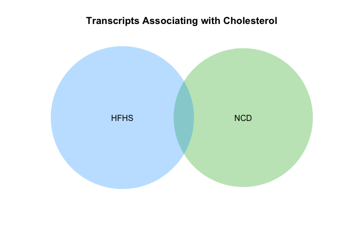

```r
library(venneuler)
vd.all <- venneuler(c("NCD"=dim(sig.twas.data.ncd)[1],
                      "HFHS"=dim(sig.twas.data.hf)[1],
                      "NCD&HFHS"=intersect(sig.twas.data.hf$symbol,sig.twas.data.ncd$symbol) %>% length()))
plot(vd.all, main="Transcripts Associating with Cholesterol")
```

## 6.1 TWAS Modification by Sex

By modeling the interactions between sex and expression on cholesterol levels, we identified **526** genes where the cholesterol/expression relationship was modified by sex in a nominally significant manner. This included 14 genes where the relationship was stronger in males, and 512 where it was stronger in females.

# 7 Comparason with mouse GWAS

```r
chr11.genes <- c('Znrf3', 'Xbp1', 'Ccdc117', 'Ankrd36', 'Mrps24', 'Urgcp', 'Dbnl', 'Pgam2', 'Polm', 'Aebp1','Pold2', 'Myl7', 'Gck', 'Ykt6', 'Camk2b', 'Nudcd3', 'A730071L15Rik', 'Npc1l1', 'Ddx56','Tmed4')
genes.of.interest <- c('Cyp7a1','Fasn','Ldlr','Hmgcr')
twas.data.ncd %>%
  filter(symbol %in% c(chr11.genes,genes.of.interest)) %>%
  kable(caption="Genes in the chromosome 11 interval with liver expression")
```

Genes in the chromosome 11 interval with liver expression

| ENSEMBL.ID | term | estimate | std.error | statistic | p.value | p.adj | symbol |
| --- | --- | --- | --- | --- | --- | --- | --- |
| ENSMUSG00000002741 | chol2 | -0.014 | 0.008 | -1.699 | 0.093 | 0.093 | Ykt6 |
| ENSMUSG00000004394 | chol2 | -0.008 | 0.006 | -1.381 | 0.170 | 0.170 | Tmed4 |
| ENSMUSG00000041798 | chol2 | 0.055 | 0.053 | 1.027 | 0.307 | 0.307 | Gck |
| ENSMUSG00000020484 | chol2 | -0.064 | 0.079 | -0.812 | 0.419 | 0.419 | Xbp1 |
| ENSMUSG00000021670 | chol2 | 0.050 | 0.091 | 0.556 | 0.580 | 0.580 | Hmgcr |
| ENSMUSG00000028240 | chol2 | -0.049 | 0.138 | -0.355 | 0.724 | 0.724 | Cyp7a1 |
| ENSMUSG00000032193 | chol2 | -0.004 | 0.043 | -0.090 | 0.928 | 0.928 | Ldlr |
| ENSMUSG00000025153 | chol2 | 0.050 | 0.636 | 0.078 | 0.938 | 0.938 | Fasn |

# 8 Integrated TWAS Analysis

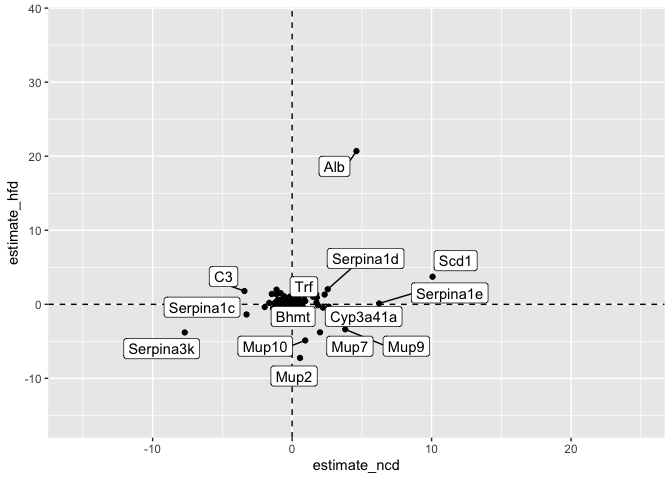

```r
combined.twas.data <-
  full_join(twas.data.ncd, twas.data.hf, by=c('ENSEMBL.ID','term','symbol'), suffix=c('_ncd','_hfd'))

combined.twas.data.all <-
  full_join(twas.data.ncd.all, twas.data.hf.all, by=c('ENSEMBL.ID','symbol'), suffix=c('_ncd','_hfd'))

library(ggplot2)
library(ggrepel)
ggplot(combined.twas.data,
       aes(y=estimate_hfd, x=estimate_ncd,
           xmin=estimate_ncd-std.error_ncd, xmax=estimate_ncd+std.error_ncd,
           ymin=estimate_hfd-std.error_hfd, ymax=estimate_hfd+std.error_hfd )) +
  geom_point() +
  #geom_errorbar() +
  #geom_errorbarh() +
  geom_hline(yintercept = 0, lty=2) +
  geom_vline(xintercept = 0, lty=2) +
  geom_label_repel(aes(label=symbol),
                   data = subset(combined.twas.data, abs(estimate_hfd) > 2|abs(estimate_ncd) > 2))
```

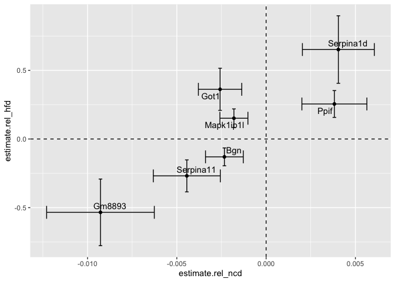

```r
sig.genes <- filter(combined.twas.data, p.adj_ncd<0.05&p.adj_hfd<0.05) %>% pull(symbol)
ggplot(combined.twas.data.all %>% filter(symbol %in% sig.genes),
       aes(y=estimate.rel_hfd, x=estimate.rel_ncd,
           xmin=estimate.rel_ncd-std.error.rel_ncd,
           xmax=estimate.rel_ncd+std.error.rel_ncd,
           ymin=estimate.rel_hfd-std.error.rel_hfd,
           ymax=estimate.rel_hfd+std.error.rel_hfd )) +
  geom_point() +
  geom_errorbar() +
  geom_errorbarh() +
  geom_hline(yintercept = 0, lty=2) +
  geom_vline(xintercept = 0, lty=2) +
  geom_text_repel(aes(label=symbol))
```

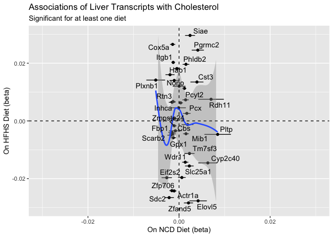

```r
sig.genes <- filter(combined.twas.data, p.adj_ncd<0.05|p.adj_hfd<0.05) %>% pull(symbol)
ggplot(combined.twas.data.all %>% filter(symbol %in% sig.genes),
       aes(y=estimate.rel_hfd, x=estimate.rel_ncd,
           xmin=estimate.rel_ncd-std.error.rel_ncd,
           xmax=estimate.rel_ncd+std.error.rel_ncd,
           ymin=estimate.rel_hfd-std.error.rel_hfd,
           ymax=estimate.rel_hfd+std.error.rel_hfd )) +
  geom_point() +
  geom_errorbar() +
  geom_errorbarh() +
  geom_smooth() +
  geom_hline(yintercept = 0, lty=2) +
  geom_vline(xintercept = 0, lty=2) +
  xlim(-0.03,0.03) +
  ylim(-0.03,0.03) +
  geom_text_repel(aes(label=symbol)) +
  labs(y="On HFHS Diet (beta)",
       x="On NCD Diet (beta)",
       title="Associations of Liver Transcripts with Cholesterol",
       subtitle="Significant for at least one diet")
```

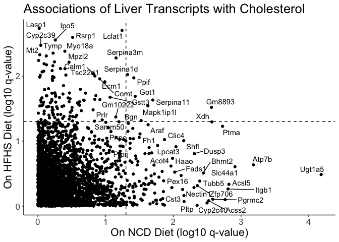

```r
cutoff <- -log10(0.05)
ggplot(combined.twas.data,
       aes(y=-log10(p.adj_hfd), x=-log10(p.adj_ncd) )) +
  geom_point() +
  #geom_errorbar() +
  #geom_errorbarh() +
  geom_hline(yintercept = -log10(0.05), lty=2) +
  geom_vline(xintercept = -log10(0.05), lty=2) +
  geom_text_repel(aes(label=symbol),
                   data = subset(combined.twas.data, -log10(p.adj_hfd) > cutoff|-log10(p.adj_ncd) > cutoff)) +
  labs(y="On HFHS Diet (log10 q-value)",
       x="On NCD Diet (log10 q-value)",
       title="Associations of Liver Transcripts with Cholesterol") +
  theme_classic() +
  theme(text=element_text(size=16))
```

# Comparason with human GWAS